# 7_abq_ml_exploration_time_freq_rf_time_from_noon_directional_diff_ratio-Copy1

1 Ground predictions

1.1 PVLib Clearsky

2 Train/test on NSRDB data to find optimal parameters

2.1 Default classifier

2.2 Gridsearch

3 Train on all NSRDB data, test various freq of ground data

3.1 30 min freq ground data

3.2 15 min freq ground data

3.3 10 min freq ground data

3.4 5 min freq ground data

3.5 1 min freq ground data

4 Save model

5 Conclusion

```python
import pandas as pd
import numpy as np
import os
import datetime
import matplotlib
import matplotlib.pyplot as plt
from mpl_toolkits.axes_grid1 import make_axes_locatable
from sklearn import tree
from sklearn import ensemble

import pytz
import itertools
import visualize
import utils
import pydotplus
import xgboost as xgb

from sklearn import metrics
from sklearn import model_selection

import pvlib
import cs_detection

import visualize_plotly as visualize
from plotly.offline import download_plotlyjs, init_notebook_mode, plot, iplot
import plotly.graph_objs as go
init_notebook_mode(connected=True)

from IPython.display import Image

%load_ext autoreload
%autoreload 2

np.set_printoptions(precision=4)
%matplotlib notebook
```

```
The autoreload extension is already loaded. To reload it, use:
  %reload_ext autoreload
```

# Ground predictions

## PVLib Clearsky

Only making ground predictions using PVLib clearsky model and statistical model. NSRDB model won't be available to ground measurements.

```python
nsrdb = cs_detection.ClearskyDetection.read_pickle('abq_nsrdb_1.pkl.gz')
nsrdb.df.index = nsrdb.df.index.tz_convert('MST')
nsrdb.time_from_solar_noon('Clearsky GHI pvlib', 'tfn')
```

# Train/test on NSRDB data to find optimal parameters

## Default classifier

```python
train = cs_detection.ClearskyDetection(nsrdb.df, scale_col=None)
train.trim_dates(None, '01-01-2015')
test = cs_detection.ClearskyDetection(nsrdb.df, scale_col=None)
test.trim_dates('01-01-2015', None)
```

```python
train.scale_model('GHI', 'Clearsky GHI pvlib', 'sky_status')
```

```python
clf = ensemble.RandomForestClassifier(random_state=42)
```

```python
utils.calc_all_window_metrics(train.df, 3, meas_col='GHI', model_col='Clearsky GHI pvlib', overwrite=True)
```

```python
train.df.keys()
```

```
Index(['GHI', 'Clearsky GHI', 'Cloud Type', 'sky_status', 'Clearsky GHI pvlib',
       'Clearsky GHI stat', 'Clearsky GHI stat smooth', 'ghi_status', 'scale',
       'tfn', 'GHI gradient', 'GHI gradient second',
       'Clearsky GHI pvlib gradient', 'Clearsky GHI pvlib gradient second',
       'abs_ideal_ratio_diff', 'abs_ideal_ratio_diff mean',
       'abs_ideal_ratio_diff std', 'abs_ideal_ratio_diff max',
       'abs_ideal_ratio_diff min', 'abs_ideal_ratio_diff grad',
       'abs_ideal_ratio_diff grad mean', 'abs_ideal_ratio_diff grad std',
       'abs_ideal_ratio_diff grad max', 'abs_ideal_ratio_diff grad min',
       'abs_ideal_ratio_diff grad second',
       'abs_ideal_ratio_diff grad second mean',
       'abs_ideal_ratio_diff grad second std',
       'abs_ideal_ratio_diff grad second max',
       'abs_ideal_ratio_diff grad second min', 'GHI line length',
       'Clearsky GHI pvlib line length',
       'GHI Clearsky GHI pvlib line length ratio',
       'GHI Clearsky GHI pvlib ratio', 'GHI Clearsky GHI pvlib ratio mean',
       'GHI Clearsky GHI pvlib ratio std', 'GHI Clearsky GHI pvlib ratio max',
       'GHI Clearsky GHI pvlib ratio min', 'GHI Clearsky GHI pvlib diff',
       'GHI Clearsky GHI pvlib diff mean', 'GHI Clearsky GHI pvlib diff std',
       'GHI Clearsky GHI pvlib diff max', 'GHI Clearsky GHI pvlib diff min',
       'GHI Clearsky GHI pvlib abs_diff',
       'GHI Clearsky GHI pvlib abs_diff mean',
       'GHI Clearsky GHI pvlib abs_diff std',
       'GHI Clearsky GHI pvlib abs_diff max',
       'GHI Clearsky GHI pvlib abs_diff min'],
      dtype='object')
```

```python
feature_cols = [
    'tfn',
#     'ghi_status',
#     'abs_ideal_ratio_diff',
#     'abs_ideal_ratio_diff mean',
#     'abs_ideal_ratio_diff std',
    'abs_ideal_ratio_diff grad',
    'abs_ideal_ratio_diff grad mean',
    'abs_ideal_ratio_diff grad std',
    'abs_ideal_ratio_diff grad second',
    'abs_ideal_ratio_diff grad second mean',
    'abs_ideal_ratio_diff grad second std',
    'GHI Clearsky GHI pvlib line length ratio',
    'GHI Clearsky GHI pvlib ratio',
    'GHI Clearsky GHI pvlib ratio mean',
    'GHI Clearsky GHI pvlib ratio std',
    'GHI Clearsky GHI pvlib diff',
    'GHI Clearsky GHI pvlib diff mean',
    'GHI Clearsky GHI pvlib diff std'
]

target_cols = ['sky_status']
```

```python
for k in feature_cols:
    print(k, train.df[k].isnull().values.any())
```

```
tfn False
abs_ideal_ratio_diff grad False
abs_ideal_ratio_diff grad mean False
abs_ideal_ratio_diff grad std False
abs_ideal_ratio_diff grad second False
abs_ideal_ratio_diff grad second mean False
abs_ideal_ratio_diff grad second std False
GHI Clearsky GHI pvlib line length ratio False
GHI Clearsky GHI pvlib ratio False
GHI Clearsky GHI pvlib ratio mean False
GHI Clearsky GHI pvlib ratio std False
GHI Clearsky GHI pvlib diff False
GHI Clearsky GHI pvlib diff mean False
GHI Clearsky GHI pvlib diff std False
```

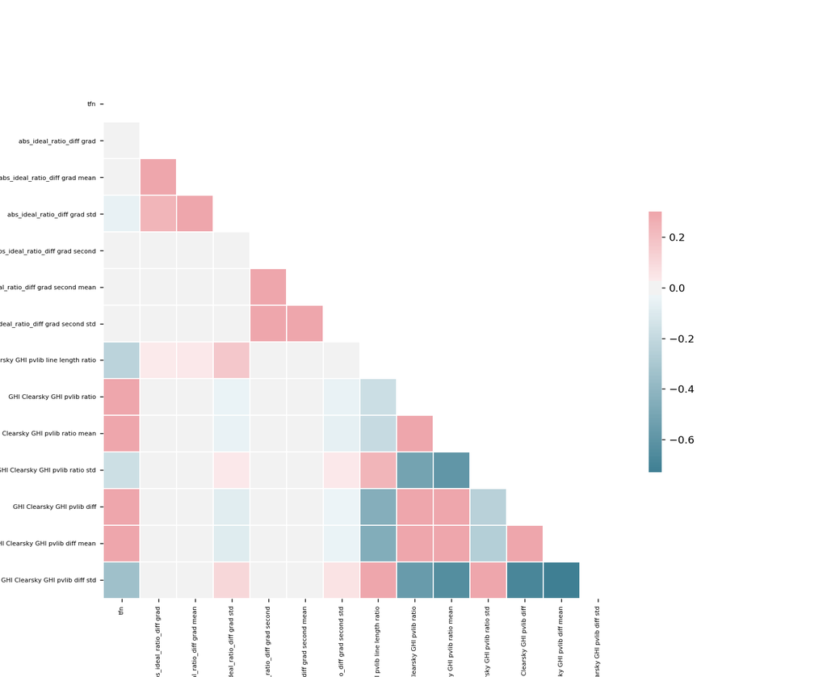

```python
vis = visualize.Visualizer()
vis.plot_corr_matrix(train.df[feature_cols].corr(), feature_cols)
```

```python
train = cs_detection.ClearskyDetection(nsrdb.df, scale_col=None)
train.trim_dates(None, '01-01-2015')
test = cs_detection.ClearskyDetection(nsrdb.df, scale_col=None)
test.trim_dates('01-01-2015', None)
```

```python
%%time
utils.calc_all_window_metrics(train.df, 3, meas_col='GHI', model_col='Clearsky GHI pvlib', overwrite=True)
clf.fit(train.df[feature_cols].values, train.df[target_cols].values.flatten())
# clf.fit(train.df[train.df['GHI'] > 0][feature_cols].values, train.df[train.df['GHI'] > 0][target_cols].values.flatten())
```

```
CPU times: user 18.2 s, sys: 481 ms, total: 18.7 s
Wall time: 18.8 s
```

```python
%%time
pred = test.iter_predict_daily(feature_cols, 'GHI', 'Clearsky GHI pvlib', clf, 3, multiproc=False, by_day=False).astype(bool)
```

[output not shown]

```python
metrics.accuracy_score(test.df['sky_status'], pred)
```

```
0.93898401826484024
```

```python
vis = visualize.Visualizer()
vis.add_line_ser(test.df['GHI'], 'GHI')
vis.add_line_ser(test.df['Clearsky GHI pvlib'], 'GHI_cs')
vis.add_circle_ser(test.df[(test.df['sky_status'] == 0) & (pred)]['GHI'], 'ML clear only')
vis.add_circle_ser(test.df[(test.df['sky_status'] == 1) & (~pred)]['GHI'], 'NSRDB clear only')
vis.add_circle_ser(test.df[(test.df['sky_status'] == 1) & (pred)]['GHI'], 'ML+NSRDB clear only')
vis.show()
```

[interactive chart not shown]

```python
cm = metrics.confusion_matrix(test.df['sky_status'].values, pred)
vis = visualize.Visualizer()
vis.plot_confusion_matrix(cm, labels=['cloudy', 'clear'])
```

[interactive chart not shown]

```python
bar = go.Bar(x=feature_cols, y=clf.feature_importances_)
iplot([bar])
```

[interactive chart not shown]

## Gridsearch

```python
import warnings
```

```python
with warnings.catch_warnings():
    warnings.simplefilter('ignore')
    params={}
    params['max_depth'] = [4, 8, 12, 16]
    params['n_estimators'] = [64]
    params['class_weight'] = [None, 'balanced']
    params['min_samples_leaf'] = [1, 2, 3]
    results = []
    for depth, nest, cw, min_samples in itertools.product(params['max_depth'], params['n_estimators'], params['class_weight'], params['min_samples_leaf']):
        print('Params:')
        print('depth: {}, n_estimators: {}, class_weight: {}, min_samples_leaf: {}'.format(depth, nest, cw, min_samples))
        train2 = cs_detection.ClearskyDetection(train.df)
        train2.trim_dates('01-01-1999', '01-01-2014')
        utils.calc_all_window_metrics(train2.df, 3, meas_col='GHI', model_col='Clearsky GHI pvlib', overwrite=True)
        test2 = cs_detection.ClearskyDetection(train.df)
        test2.trim_dates('01-01-2014', '01-01-2015')
        clf = ensemble.RandomForestClassifier(max_depth=depth, n_estimators=nest, class_weight=cw, min_samples_leaf=min_samples, n_jobs=-1)
        clf.fit(train2.df[train2.df['GHI'] > 0][feature_cols].values, train2.df[train2.df['GHI'] > 0][target_cols].values.flatten())

        print('\t Scores:')
        test_pred = test2.iter_predict_daily(feature_cols, 'GHI', 'Clearsky GHI pvlib', clf, 3, multiproc=True, by_day=True)
        accuracy_score = metrics.accuracy_score(test2.df['sky_status'], test_pred)
        print('\t\t accuracy: {}'.format(accuracy_score))
        f1_score = metrics.f1_score(test2.df['sky_status'], test_pred)
        print('\t\t f1:{}'.format(f1_score))
        recall_score = metrics.recall_score(test2.df['sky_status'], test_pred)
        print('\t\t recall:{}'.format(recall_score))
        precision_score = metrics.precision_score(test2.df['sky_status'], test_pred)
        print('\t\t precision:{}'.format(precision_score))
        results.append({'max_depth': depth, 'n_estimators': nest, 'class_weight': cw, 'min_samples_leaf': min_samples,
                        'accuracy': accuracy_score, 'f1': f1_score, 'recall': recall_score, 'precision': precision_score})
```

```
Params:
depth: 4, n_estimators: 64, class_weight: None, min_samples_leaf: 1
	 Scores:
		 accuracy: 0.9494292237442923
		 f1:0.9100507614213197
		 recall:0.9323902641980445
		 precision:0.8887566924449732
Params:
depth: 4, n_estimators: 64, class_weight: None, min_samples_leaf: 2
	 Scores:
		 accuracy: 0.9488584474885845
		 f1:0.9090539991879821
		 recall:0.9315581443727897
		 precision:0.8876114965312191
Params:
depth: 4, n_estimators: 64, class_weight: None, min_samples_leaf: 3
	 Scores:
		 accuracy: 0.9493721461187214
		 f1:0.9101226061404398
		 recall:0.9342625338048679
		 precision:0.8871987356775978
Params:
depth: 4, n_estimators: 64, class_weight: balanced, min_samples_leaf: 1
	 Scores:
		 accuracy: 0.9481164383561644
		 f1:0.9073300030584157
		 recall:0.9257333055960059
		 precision:0.8896441423430628
Params:
depth: 4, n_estimators: 64, class_weight: balanced, min_samples_leaf: 2
	 Scores:
		 accuracy: 0.9485730593607306
		 f1:0.9081455805892549
		 recall:0.9265654254212606
		 precision:0.8904438224710116
Params:
depth: 4, n_estimators: 64, class_weight: balanced, min_samples_leaf: 3
	 Scores:
		 accuracy: 0.948458904109589
		 f1:0.9077912794853467
```

[output cut: 113 more lines]

```
		 precision:0.8855409900215222
Params:
depth: 16, n_estimators: 64, class_weight: balanced, min_samples_leaf: 2
	 Scores:
		 accuracy: 0.9507420091324201
		 f1:0.9130478589420654
		 recall:0.9425837320574163
		 precision:0.885306760453302
Params:
depth: 16, n_estimators: 64, class_weight: balanced, min_samples_leaf: 3
	 Scores:
		 accuracy: 0.9500570776255708
		 f1:0.9117498739283915
		 recall:0.9402954025379655
		 precision:0.884886452623336
```

```python
runs_df = pd.DataFrame(results)
```

```python
runs_df.sort_values('accuracy', ascending=False)
```

|  | accuracy | class_weight | f1 | max_depth | min_samples_leaf | n_estimators | precision | recall |
| --- | --- | --- | --- | --- | --- | --- | --- | --- |
| 8 | 0.952055 | None | 0.915306 | 8 | 3 | 64 | 0.888085 | 0.944248 |
| 13 | 0.951884 | None | 0.915319 | 12 | 2 | 64 | 0.885004 | 0.947784 |
| 7 | 0.951884 | None | 0.914977 | 8 | 2 | 64 | 0.888019 | 0.943624 |
| 14 | 0.951826 | None | 0.915176 | 12 | 3 | 64 | 0.885281 | 0.947160 |
| 6 | 0.951826 | None | 0.914902 | 8 | 1 | 64 | 0.887693 | 0.943832 |
| 11 | 0.951655 | balanced | 0.914297 | 8 | 3 | 64 | 0.890071 | 0.939879 |
| 15 | 0.951484 | balanced | 0.914176 | 12 | 1 | 64 | 0.888170 | 0.941752 |
| 20 | 0.951484 | None | 0.914556 | 16 | 3 | 64 | 0.884847 | 0.946328 |
| 9 | 0.951484 | balanced | 0.913950 | 8 | 1 | 64 | 0.890160 | 0.939047 |
| 10 | 0.951256 | balanced | 0.913493 | 8 | 2 | 64 | 0.890227 | 0.938007 |
| 12 | 0.951256 | None | 0.914102 | 12 | 1 | 64 | 0.884907 | 0.945288 |
| 19 | 0.951142 | None | 0.913883 | 16 | 2 | 64 | 0.884863 | 0.944872 |
| 18 | 0.951027 | None | 0.913855 | 16 | 1 | 64 | 0.883175 | 0.946744 |
| 16 | 0.950856 | balanced | 0.912916 | 12 | 2 | 64 | 0.888386 | 0.938839 |
| 17 | 0.950742 | balanced | 0.912643 | 12 | 3 | 64 | 0.888801 | 0.937799 |
| 22 | 0.950742 | balanced | 0.913048 | 16 | 2 | 64 | 0.885307 | 0.942584 |
| 21 | 0.950571 | balanced | 0.912684 | 16 | 1 | 64 | 0.885541 | 0.941544 |
| 23 | 0.950057 | balanced | 0.911750 | 16 | 3 | 64 | 0.884886 | 0.940295 |
| 0 | 0.949429 | None | 0.910051 | 4 | 1 | 64 | 0.888757 | 0.932390 |
| 2 | 0.949372 | None | 0.910123 | 4 | 3 | 64 | 0.887199 | 0.934263 |
| 1 | 0.948858 | None | 0.909054 | 4 | 2 | 64 | 0.887611 | 0.931558 |
| 4 | 0.948573 | balanced | 0.908146 | 4 | 2 | 64 | 0.890444 | 0.926565 |
| 5 | 0.948459 | balanced | 0.907791 | 4 | 3 | 64 | 0.891496 | 0.924693 |
| 3 | 0.948116 | balanced | 0.907330 | 4 | 1 | 64 | 0.889644 | 0.925733 |

```python
runs_df.sort_values('f1', ascending=False)
```

|  | accuracy | class_weight | f1 | max_depth | min_samples_leaf | n_estimators | precision | recall |
| --- | --- | --- | --- | --- | --- | --- | --- | --- |
| 13 | 0.951884 | None | 0.915319 | 12 | 2 | 64 | 0.885004 | 0.947784 |
| 8 | 0.952055 | None | 0.915306 | 8 | 3 | 64 | 0.888085 | 0.944248 |
| 14 | 0.951826 | None | 0.915176 | 12 | 3 | 64 | 0.885281 | 0.947160 |
| 7 | 0.951884 | None | 0.914977 | 8 | 2 | 64 | 0.888019 | 0.943624 |
| 6 | 0.951826 | None | 0.914902 | 8 | 1 | 64 | 0.887693 | 0.943832 |
| 20 | 0.951484 | None | 0.914556 | 16 | 3 | 64 | 0.884847 | 0.946328 |
| 11 | 0.951655 | balanced | 0.914297 | 8 | 3 | 64 | 0.890071 | 0.939879 |
| 15 | 0.951484 | balanced | 0.914176 | 12 | 1 | 64 | 0.888170 | 0.941752 |
| 12 | 0.951256 | None | 0.914102 | 12 | 1 | 64 | 0.884907 | 0.945288 |
| 9 | 0.951484 | balanced | 0.913950 | 8 | 1 | 64 | 0.890160 | 0.939047 |
| 19 | 0.951142 | None | 0.913883 | 16 | 2 | 64 | 0.884863 | 0.944872 |
| 18 | 0.951027 | None | 0.913855 | 16 | 1 | 64 | 0.883175 | 0.946744 |
| 10 | 0.951256 | balanced | 0.913493 | 8 | 2 | 64 | 0.890227 | 0.938007 |
| 22 | 0.950742 | balanced | 0.913048 | 16 | 2 | 64 | 0.885307 | 0.942584 |
| 16 | 0.950856 | balanced | 0.912916 | 12 | 2 | 64 | 0.888386 | 0.938839 |
| 21 | 0.950571 | balanced | 0.912684 | 16 | 1 | 64 | 0.885541 | 0.941544 |
| 17 | 0.950742 | balanced | 0.912643 | 12 | 3 | 64 | 0.888801 | 0.937799 |
| 23 | 0.950057 | balanced | 0.911750 | 16 | 3 | 64 | 0.884886 | 0.940295 |
| 2 | 0.949372 | None | 0.910123 | 4 | 3 | 64 | 0.887199 | 0.934263 |
| 0 | 0.949429 | None | 0.910051 | 4 | 1 | 64 | 0.888757 | 0.932390 |
| 1 | 0.948858 | None | 0.909054 | 4 | 2 | 64 | 0.887611 | 0.931558 |
| 4 | 0.948573 | balanced | 0.908146 | 4 | 2 | 64 | 0.890444 | 0.926565 |
| 5 | 0.948459 | balanced | 0.907791 | 4 | 3 | 64 | 0.891496 | 0.924693 |
| 3 | 0.948116 | balanced | 0.907330 | 4 | 1 | 64 | 0.889644 | 0.925733 |